# Simplilearn Post Graduate Program - Data Science - In Partnership With Purdue University

Project Report - Income Qualification Prediction

Organization: **Simplilearn - Purdue University**  
Batch: **PGP DS Mar 2022 COHORT 2**  
Course: **PG DS - Machine Learning**  
Project: **Income Qualification Prediction**  
Programming Language: **Python**  
Submitted by: **Lavkush Singh**

## Problem Statement

**The project aims at building a model to predict Income Qualification, given various attributes collected across the household and the people of Latin America, using Machine Learning.**

##### Analysis Tasks to be performed

- Identify the output variable.
- Understand the type of data.
- Check if there are any biases in your dataset.
- Check whether all members of the house have the same poverty level.
- Check if there is a house without a family head.
- Set poverty level of the members and the head of the house within a family.
- Count how many null values are existing in columns.
- Remove null value rows of the target variable.
- Predict the accuracy using random forest classifier.
- Check the accuracy using random forest with cross validation.

```python
# Importing required libraries

import numpy as np
import pandas as pd
import matplotlib.pyplot as plt
import seaborn as sns
from sklearn.model_selection import train_test_split
from sklearn.preprocessing import MinMaxScaler
from sklearn.decomposition import PCA
from sklearn.ensemble import RandomForestClassifier
from sklearn.model_selection import GridSearchCV, KFold, cross_val_score
from sklearn.metrics import accuracy_score, classification_report, confusion_matrix, ConfusionMatrixDisplay, multilabel_confusion_matrix
```

```python
# settings to display all columns

pd.set_option("display.max_columns", None)
pd.options.display.max_rows = None
```

```python
# reading the data

train_data = pd.read_csv('Dataset/train.csv')
test_data = pd.read_csv('Dataset/test.csv')
```

```python
train_data.head() # viewing first few observations of train dataset
```

|  | Id | v2a1 | hacdor | rooms | hacapo | v14a | refrig | v18q | v18q1 | r4h1 | r4h2 | r4h3 | r4m1 | r4m2 | r4m3 | r4t1 | r4t2 | r4t3 | tamhog | tamviv | escolari | rez_esc | hhsize | paredblolad | paredzocalo | paredpreb | pareddes | paredmad | paredzinc | … |
| --- | --- | --- | --- | --- | --- | --- | --- | --- | --- | --- | --- | --- | --- | --- | --- | --- | --- | --- | --- | --- | --- | --- | --- | --- | --- | --- | --- | --- | --- | --- |
| 0 | ID_279628684 | 190000.0 | 0 | 3 | 0 | 1 | 1 | 0 | NaN | 0 | 1 | 1 | 0 | 0 | 0 | 0 | 1 | 1 | 1 | 1 | 10 | NaN | 1 | 1 | 0 | 0 | 0 | 0 | 0 | … |
| 1 | ID_f29eb3ddd | 135000.0 | 0 | 4 | 0 | 1 | 1 | 1 | 1.0 | 0 | 1 | 1 | 0 | 0 | 0 | 0 | 1 | 1 | 1 | 1 | 12 | NaN | 1 | 0 | 0 | 0 | 0 | 1 | 0 | … |
| 2 | ID_68de51c94 | NaN | 0 | 8 | 0 | 1 | 1 | 0 | NaN | 0 | 0 | 0 | 0 | 1 | 1 | 0 | 1 | 1 | 1 | 1 | 11 | NaN | 1 | 0 | 0 | 0 | 0 | 1 | 0 | … |
| 3 | ID_d671db89c | 180000.0 | 0 | 5 | 0 | 1 | 1 | 1 | 1.0 | 0 | 2 | 2 | 1 | 1 | 2 | 1 | 3 | 4 | 4 | 4 | 9 | 1.0 | 4 | 1 | 0 | 0 | 0 | 0 | 0 | … |
| 4 | ID_d56d6f5f5 | 180000.0 | 0 | 5 | 0 | 1 | 1 | 1 | 1.0 | 0 | 2 | 2 | 1 | 1 | 2 | 1 | 3 | 4 | 4 | 4 | 11 | NaN | 4 | 1 | 0 | 0 | 0 | 0 | 0 | … |

```python
test_data.head() # viewing first few observations of test dataset
```

|  | Id | v2a1 | hacdor | rooms | hacapo | v14a | refrig | v18q | v18q1 | r4h1 | r4h2 | r4h3 | r4m1 | r4m2 | r4m3 | r4t1 | r4t2 | r4t3 | tamhog | tamviv | escolari | rez_esc | hhsize | paredblolad | paredzocalo | paredpreb | pareddes | paredmad | paredzinc | … |
| --- | --- | --- | --- | --- | --- | --- | --- | --- | --- | --- | --- | --- | --- | --- | --- | --- | --- | --- | --- | --- | --- | --- | --- | --- | --- | --- | --- | --- | --- | --- |
| 0 | ID_2f6873615 | NaN | 0 | 5 | 0 | 1 | 1 | 0 | NaN | 1 | 1 | 2 | 0 | 1 | 1 | 1 | 2 | 3 | 3 | 3 | 0 | NaN | 3 | 1 | 0 | 0 | 0 | 0 | 0 | … |
| 1 | ID_1c78846d2 | NaN | 0 | 5 | 0 | 1 | 1 | 0 | NaN | 1 | 1 | 2 | 0 | 1 | 1 | 1 | 2 | 3 | 3 | 3 | 16 | NaN | 3 | 1 | 0 | 0 | 0 | 0 | 0 | … |
| 2 | ID_e5442cf6a | NaN | 0 | 5 | 0 | 1 | 1 | 0 | NaN | 1 | 1 | 2 | 0 | 1 | 1 | 1 | 2 | 3 | 3 | 3 | 17 | NaN | 3 | 1 | 0 | 0 | 0 | 0 | 0 | … |
| 3 | ID_a8db26a79 | NaN | 0 | 14 | 0 | 1 | 1 | 1 | 1.0 | 0 | 1 | 1 | 0 | 0 | 0 | 0 | 1 | 1 | 1 | 1 | 16 | NaN | 1 | 1 | 0 | 0 | 0 | 0 | 0 | … |
| 4 | ID_a62966799 | 175000.0 | 0 | 4 | 0 | 1 | 1 | 1 | 1.0 | 0 | 0 | 0 | 0 | 1 | 1 | 0 | 1 | 1 | 1 | 1 | 11 | NaN | 1 | 1 | 0 | 0 | 0 | 0 | 0 | … |

### Task 1: Identify the output variable.

```python
print("The output variable is 'Target' of train_data (level of income qualification)")
```

```
The output variable is 'Target' of train_data (level of income qualification)
```

### Task 2: Understand the type of data.

```python
train_data.shape # checking rows and cols of the train dataset
```

```
(9557, 143)
```

```python
train_data.dtypes.value_counts()  # count of distinct datatype of columns present in the dataset
```

```
int64      130
float64      8
object       5
dtype: int64
```

```python
test_data.shape  # checking rows and cols of the test dataset
```

```
(23856, 142)
```

```python
test_data.dtypes.value_counts()
```

```
int64      129
float64      8
object       5
dtype: int64
```

```python
print('The datatypes varies across int, float and object. Further inspection is needed to ensure the data is consistant with the datatype of the columns')
```

```
The datatypes varies across int, float and object. Further inspection is needed to ensure the data is consistant with the datatype of the columns
```

### Task 3, 7, 8: Check if there are any biases and Null Values in your dataset and remove the Null Values

```python
train_data.head(n = 3)
```

|  | Id | v2a1 | hacdor | rooms | hacapo | v14a | refrig | v18q | v18q1 | r4h1 | r4h2 | r4h3 | r4m1 | r4m2 | r4m3 | r4t1 | r4t2 | r4t3 | tamhog | tamviv | escolari | rez_esc | hhsize | paredblolad | paredzocalo | paredpreb | pareddes | paredmad | paredzinc | … |
| --- | --- | --- | --- | --- | --- | --- | --- | --- | --- | --- | --- | --- | --- | --- | --- | --- | --- | --- | --- | --- | --- | --- | --- | --- | --- | --- | --- | --- | --- | --- |
| 0 | ID_279628684 | 190000.0 | 0 | 3 | 0 | 1 | 1 | 0 | NaN | 0 | 1 | 1 | 0 | 0 | 0 | 0 | 1 | 1 | 1 | 1 | 10 | NaN | 1 | 1 | 0 | 0 | 0 | 0 | 0 | … |
| 1 | ID_f29eb3ddd | 135000.0 | 0 | 4 | 0 | 1 | 1 | 1 | 1.0 | 0 | 1 | 1 | 0 | 0 | 0 | 0 | 1 | 1 | 1 | 1 | 12 | NaN | 1 | 0 | 0 | 0 | 0 | 1 | 0 | … |
| 2 | ID_68de51c94 | NaN | 0 | 8 | 0 | 1 | 1 | 0 | NaN | 0 | 0 | 0 | 0 | 1 | 1 | 0 | 1 | 1 | 1 | 1 | 11 | NaN | 1 | 0 | 0 | 0 | 0 | 1 | 0 | … |

```python
test_data.head(n = 3)
```

|  | Id | v2a1 | hacdor | rooms | hacapo | v14a | refrig | v18q | v18q1 | r4h1 | r4h2 | r4h3 | r4m1 | r4m2 | r4m3 | r4t1 | r4t2 | r4t3 | tamhog | tamviv | escolari | rez_esc | hhsize | paredblolad | paredzocalo | paredpreb | pareddes | paredmad | paredzinc | … |
| --- | --- | --- | --- | --- | --- | --- | --- | --- | --- | --- | --- | --- | --- | --- | --- | --- | --- | --- | --- | --- | --- | --- | --- | --- | --- | --- | --- | --- | --- | --- |
| 0 | ID_2f6873615 | NaN | 0 | 5 | 0 | 1 | 1 | 0 | NaN | 1 | 1 | 2 | 0 | 1 | 1 | 1 | 2 | 3 | 3 | 3 | 0 | NaN | 3 | 1 | 0 | 0 | 0 | 0 | 0 | … |
| 1 | ID_1c78846d2 | NaN | 0 | 5 | 0 | 1 | 1 | 0 | NaN | 1 | 1 | 2 | 0 | 1 | 1 | 1 | 2 | 3 | 3 | 3 | 16 | NaN | 3 | 1 | 0 | 0 | 0 | 0 | 0 | … |
| 2 | ID_e5442cf6a | NaN | 0 | 5 | 0 | 1 | 1 | 0 | NaN | 1 | 1 | 2 | 0 | 1 | 1 | 1 | 2 | 3 | 3 | 3 | 17 | NaN | 3 | 1 | 0 | 0 | 0 | 0 | 0 | … |

#### Sub-Task: Checking if the datatype is consistant across the columns

```python
train_data.select_dtypes(include='object').columns  # checking columns of only object datatype
```

```
Index(['Id', 'idhogar', 'dependency', 'edjefe', 'edjefa'], dtype='object')
```

```python
test_data.select_dtypes(include='object').columns
```

```
Index(['Id', 'idhogar', 'dependency', 'edjefe', 'edjefa'], dtype='object')
```

```python
train_data.dtypes[train_data.dtypes == 'object']
```

```
Id            object
idhogar       object
dependency    object
edjefe        object
edjefa        object
dtype: object
```

```python
test_data.dtypes[train_data.dtypes == 'object']
```

```
Id            object
idhogar       object
dependency    object
edjefe        object
edjefa        object
dtype: object
```

```python
# checking if 'dependency' column has any missing values in train dataset and test dataset

train_data['dependency'].isnull().any(), test_data['dependency'].isnull().any()
```

```
(False, False)
```

```python
train_data['dependency'].unique()   # checking unique values to identify why numerical column is of object type
```

```
array(['no', '8', 'yes', '3', '.5', '.25', '2', '.66666669', '.33333334',
       '1.5', '.40000001', '.75', '1.25', '.2', '2.5', '1.2', '4',
       '1.3333334', '2.25', '.22222222', '5', '.83333331', '.80000001',
       '6', '3.5', '1.6666666', '.2857143', '1.75', '.71428573',
       '.16666667', '.60000002'], dtype=object)
```

```python
test_data['dependency'].unique()
```

```
array(['.5', 'no', '8', 'yes', '.25', '2', '.33333334', '.375',
       '.60000002', '1.5', '.2', '.75', '.66666669', '3', '.14285715',
       '.40000001', '.80000001', '1.6666666', '.2857143', '1.25', '2.5',
       '5', '.85714287', '1.3333334', '.16666667', '4', '.125',
       '.83333331', '2.3333333', '7', '1.2', '3.5', '2.25', '3.3333333',
       '6'], dtype=object)
```

```python
# getting all the values of dependency column from train dataset, except for 'yes' and 'no'

dependency_values_train = train_data[train_data['dependency'].isin(['yes', 'no']) == False]['dependency']
```

```python
# converting the obtained numerical values of dependency column from train dataset to float, to plot its distribution

dependency_values_train = dependency_values_train.astype('float64')
```

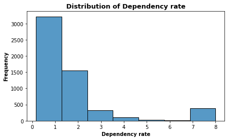

```python
plt.figure(figsize=(7,4))
sns.histplot( x = dependency_values_train, bins = 7)
plt.title('Distribution of Dependency rate', fontsize = 13, fontweight="bold")
plt.xlabel('Dependency rate', fontweight="bold")
plt.ylabel('Frequency', fontweight="bold")
plt.show()
```

Replacing 'no' with 0 and 'yes' with median of 'dependency' column

```python
train_data['dependency'] = train_data['dependency'].str.replace('no', '0')
test_data['dependency'] = test_data['dependency'].str.replace('no', '0')
```

```python
median_dependency_train = train_data[train_data['dependency'] != 'yes']['dependency'].astype('float64').median()
```

```python
train_data['dependency'] = train_data['dependency'].str.replace('yes', str(median_dependency_train)).astype('float64')
test_data['dependency'] = test_data['dependency'].str.replace('yes', str(median_dependency_train)).astype('float64')
```

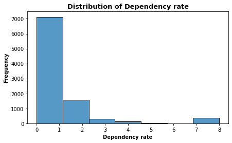

```python
plt.figure(figsize=(7,4))
sns.histplot(x = 'dependency', data = train_data, bins = 7);
plt.title('Distribution of Dependency rate', fontsize = 13, fontweight="bold")
plt.xlabel('Dependency rate', fontweight="bold")
plt.ylabel('Frequency', fontweight="bold")
plt.show()
```

Checking remaining object types column and validating them for null values and consistency.

```python
train_data.dtypes[train_data.dtypes == 'object']
```

```
Id         object
idhogar    object
edjefe     object
edjefa     object
dtype: object
```

```python
test_data.dtypes[train_data.dtypes == 'object']
```

```
Id         object
idhogar    object
edjefe     object
edjefa     object
dtype: object
```

```python
train_data[['edjefe', 'edjefa']].isnull().sum()
```

```
edjefe    0
edjefa    0
dtype: int64
```

```python
test_data[['edjefe', 'edjefa']].isnull().sum()
```

```
edjefe    0
edjefa    0
dtype: int64
```

```python
train_data['edjefe'].unique()
```

```
array(['10', '12', 'no', '11', '9', '15', '4', '6', '8', '17', '7', '16',
       '14', '5', '21', '2', '19', 'yes', '3', '18', '13', '20'],
      dtype=object)
```

```python
train_data['edjefa'].unique()
```

```
array(['no', '11', '4', '10', '9', '15', '7', '14', '13', '8', '17', '6',
       '5', '3', '16', '19', 'yes', '21', '12', '2', '20', '18'],
      dtype=object)
```

```python
test_data['edjefe'].unique()
```

```
array(['no', '16', '10', '6', '11', '8', '13', '14', '5', '3', '9', '17',
       '15', '7', '21', '4', '12', '2', '20', 'yes', '19', '18'],
      dtype=object)
```

```python
test_data['edjefa'].unique()
```

```
array(['17', 'no', '11', '14', '10', '15', '9', '6', '8', '3', '2', '5',
       '16', '12', 'yes', '7', '13', '21', '4', '19', '18', '20'],
      dtype=object)
```

```python
# Replaced 'no'values of 'edjefe', 'edjefa' columns of train and test dataset with 0

train_data[['edjefe', 'edjefa']] = train_data[['edjefe', 'edjefa']].replace('no', '0')
test_data[['edjefe', 'edjefa']] = test_data[['edjefe', 'edjefa']].replace('no', '0')
```

```python
# calculated the median value of 'edjefe', 'edjefa' columns excluding the 'yes' value. This median wil be used for imputation

edjefe_median_train = train_data[train_data['edjefe'] != 'yes']['edjefe'].astype('float64').median()
edjefa_median_train = train_data[train_data['edjefa'] != 'yes']['edjefa'].astype('float64').median()
```

```python
# imputing the median value of 'edjefe' from train data, into train and test dataset's 'edjefe' column in place of 'yes'

train_data['edjefe'] = train_data['edjefe'].str.replace('yes', str(edjefe_median_train)).astype('float64')
test_data['edjefe'] = test_data['edjefe'].str.replace('yes', str(edjefe_median_train)).astype('float64')
```

```python
# imputing the median value of 'edjefa' from train data, into train and test dataset's 'edjefe' column in place of 'yes'

train_data['edjefa'] = train_data['edjefa'].str.replace('yes', str(edjefa_median_train)).astype('float64')
test_data['edjefa'] = test_data['edjefa'].str.replace('yes', str(edjefa_median_train)).astype('float64')
```

```python
train_data.dtypes.value_counts()
```

```
int64      130
float64     11
object       2
dtype: int64
```

```python
test_data.dtypes.value_counts()
```

```
int64      129
float64     11
object       2
dtype: int64
```

There are only 2 columns of object type, 'ID' and 'idhogar'. They will be dropped before splitting the dataset into training and testing set

#### Sub-Task: In order to check bias, checking the distribution of the numerical columns via plots.

```python
non_categ_cols = [col for col in train_data.columns if ~train_data[col].isin([0,1]).all()]
non_categ_cols
```

```
['Id',
 'v2a1',
 'rooms',
 'v18q1',
 'r4h1',
 'r4h2',
 'r4h3',
 'r4m1',
 'r4m2',
 'r4m3',
 'r4t1',
 'r4t2',
 'r4t3',
 'tamhog',
 'tamviv',
 'escolari',
 'rez_esc',
 'hhsize',
 'idhogar',
 'hogar_nin',
 'hogar_adul',
 'hogar_mayor',
 'hogar_total',
 'dependency',
 'edjefe',
 'edjefa',
 'meaneduc',
 'bedrooms',
 'overcrowding',
 'qmobilephone',
 'age',
 'SQBescolari',
 'SQBage',
 'SQBhogar_total',
 'SQBedjefe',
 'SQBhogar_nin',
 'SQBovercrowding',
 'SQBdependency',
 'SQBmeaned',
 'agesq',
 'Target']
```

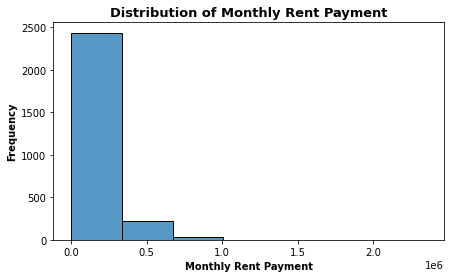

```python
plt.figure(figsize=(7,4))
sns.histplot(train_data['v2a1'], bins=7)  # Monthly Rent Payment
plt.title('Distribution of Monthly Rent Payment', fontsize = 13, fontweight="bold")
plt.xlabel('Monthly Rent Payment', fontweight="bold")
plt.ylabel('Frequency', fontweight="bold")
plt.show()
```

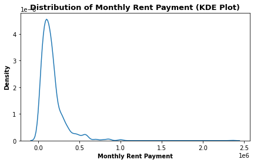

```python
plt.figure(figsize=(7,4))
sns.kdeplot(train_data['v2a1'])  # Monthly Rent Payment
plt.title('Distribution of Monthly Rent Payment (KDE Plot)', fontsize = 13, fontweight="bold")
plt.xlabel('Monthly Rent Payment', fontweight="bold")
plt.ylabel('Density', fontweight="bold")
plt.show()
```

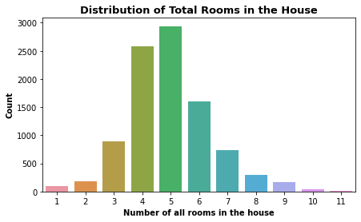

```python
plt.figure(figsize=(7,4))
sns.countplot(x = 'rooms', data = train_data)
plt.title('Distribution of Total Rooms in the House', fontsize = 13, fontweight="bold")
plt.xlabel('Number of all rooms in the house', fontweight="bold")
plt.ylabel('Count', fontweight="bold")
plt.show()
```

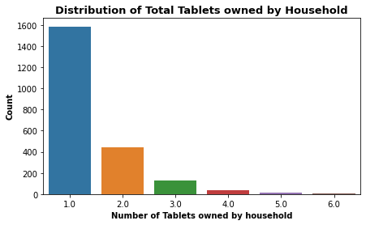

```python
plt.figure(figsize=(7,4))
sns.countplot(x = 'v18q1', data = train_data) #number of tablets household owns
plt.title('Distribution of Total Tablets owned by Household', fontsize = 13, fontweight="bold")
plt.xlabel('Number of Tablets owned by household', fontweight="bold")
plt.ylabel('Count', fontweight="bold")
plt.show()
```

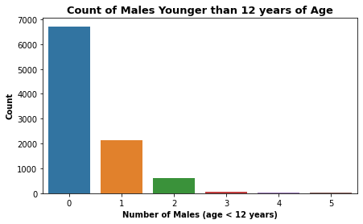

```python
plt.figure(figsize=(7,4))
sns.countplot(x = 'r4h1', data = train_data) # Males younger than 12 years of age
plt.title('Count of Males Younger than 12 years of Age', fontsize = 13, fontweight="bold")
plt.xlabel('Number of Males (age < 12 years)', fontweight="bold")
plt.ylabel('Count', fontweight="bold")
plt.show()
```

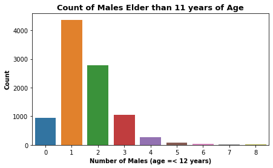

```python
plt.figure(figsize=(7,4))
sns.countplot(x = 'r4h2', data = train_data )  # Males 12 years of age and older
plt.title('Count of Males Elder than 11 years of Age', fontsize = 13, fontweight="bold")
plt.xlabel('Number of Males (age =< 12 years)', fontweight="bold")
plt.ylabel('Count', fontweight="bold")
plt.show()
```

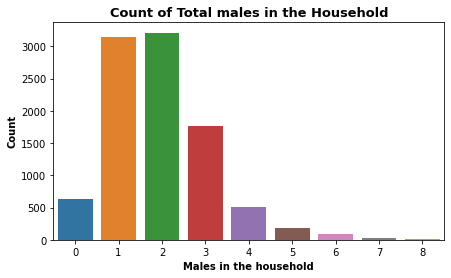

```python
plt.figure(figsize=(7,4))
sns.countplot(x = 'r4h3', data = train_data )  # Total males in the household
plt.title('Count of Total males in the Household', fontsize = 13, fontweight="bold")
plt.xlabel('Males in the household', fontweight="bold")
plt.ylabel('Count', fontweight="bold")
plt.show()
```

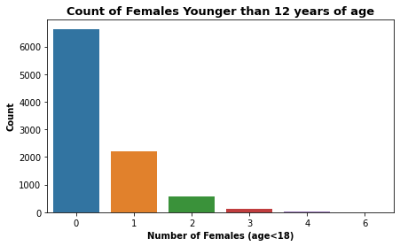

```python
plt.figure(figsize=(7,4))
sns.countplot(x = 'r4m1' , data = train_data) # Females younger than 12 years of age
plt.title('Count of Females Younger than 12 years of age', fontsize = 13, fontweight="bold")
plt.xlabel('Number of Females (age<18)', fontweight="bold")
plt.ylabel('Count', fontweight="bold")
plt.show()
```

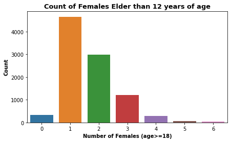

```python
plt.figure(figsize=(7,4))
sns.countplot(x = 'r4m2' , data = train_data) # Females 12 years of age and older
plt.title('Count of Females Elder than 12 years of age', fontsize = 13, fontweight="bold")
plt.xlabel('Number of Females (age>=18)', fontweight="bold")
plt.ylabel('Count', fontweight="bold")
plt.show()
```

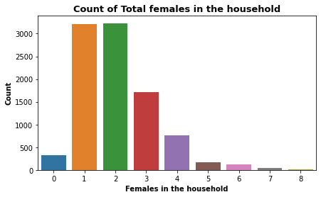

```python
plt.figure(figsize=(7,4))
sns.countplot(x = 'r4m3' , data = train_data) # Total females in the household
plt.title('Count of Total females in the household', fontsize = 13, fontweight="bold")
plt.xlabel('Females in the household', fontweight="bold")
plt.ylabel('Count', fontweight="bold")
plt.show()
```

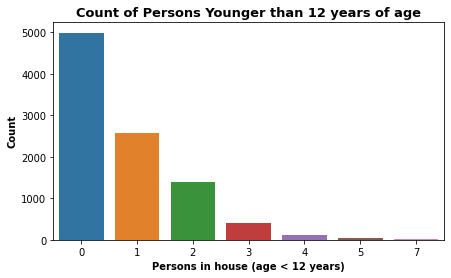

```python
plt.figure(figsize=(7,4))
sns.countplot(x = 'r4t1', data = train_data) # persons younger than 12 years of age
plt.title('Count of Persons Younger than 12 years of age', fontsize = 13, fontweight="bold")
plt.xlabel('Persons in house (age < 12 years)', fontweight="bold")
plt.ylabel('Count', fontweight="bold")
plt.show()
```

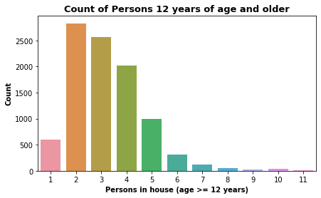

```python
plt.figure(figsize=(7,4))
sns.countplot(x = 'r4t2', data = train_data) #persons 12 years of age and older
plt.title('Count of Persons 12 years of age and older', fontsize = 13, fontweight="bold")
plt.xlabel('Persons in house (age >= 12 years)', fontweight="bold")
plt.ylabel('Count', fontweight="bold")
plt.show()
```

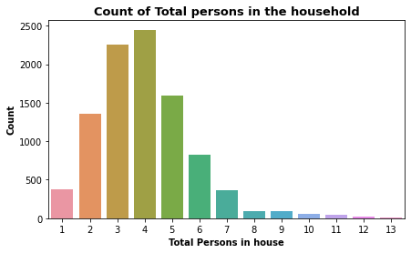

```python
plt.figure(figsize=(7,4))
sns.countplot(x = 'r4t3' , data = train_data) # Total persons in the household
plt.title('Count of Total persons in the household', fontsize = 13, fontweight="bold")
plt.xlabel('Total Persons in house', fontweight="bold")
plt.ylabel('Count', fontweight="bold")
plt.show()
```

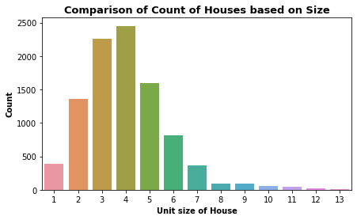

```python
plt.figure(figsize=(7,4))
sns.countplot(x = 'tamhog', data = train_data) # size of the household
plt.title('Comparison of Count of Houses based on Size', fontsize = 13, fontweight="bold")
plt.xlabel('Unit size of House', fontweight="bold")
plt.ylabel('Count', fontweight="bold")
plt.show()
```

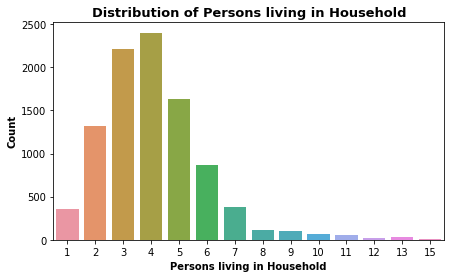

```python
plt.figure(figsize=(7,4))
sns.countplot(x = 'tamviv', data = train_data) # number of persons living in the household
plt.title('Distribution of Persons living in Household', fontsize = 13, fontweight="bold")
plt.xlabel('Persons living in Household', fontweight="bold")
plt.ylabel('Count', fontweight="bold")
plt.show()
```

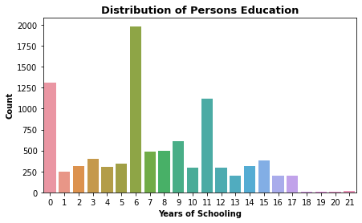

```python
plt.figure(figsize=(7,4))
sns.countplot(x = 'escolari', data = train_data ) # years of schooling
plt.title('Distribution of Persons Education', fontsize = 13, fontweight="bold")
plt.xlabel('Years of Schooling', fontweight="bold")
plt.ylabel('Count', fontweight="bold")
plt.show()
```

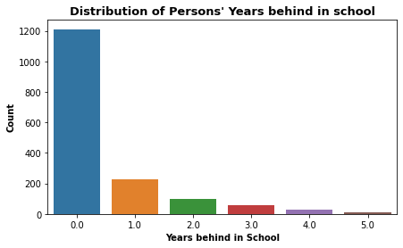

```python
plt.figure(figsize=(7,4))
sns.countplot(x = 'rez_esc', data = train_data) # Years behind in school
plt.title("Distribution of Persons' Years behind in school", fontsize = 13, fontweight="bold")
plt.xlabel('Years behind in School', fontweight="bold")
plt.ylabel('Count', fontweight="bold")
plt.show()
```

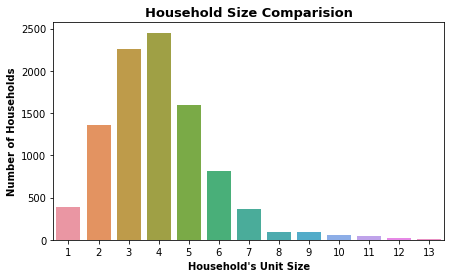

```python
plt.figure(figsize=(7,4))
sns.countplot(x = 'hhsize', data = train_data) # household size
plt.title("Household Size Comparision", fontsize = 13, fontweight="bold")
plt.xlabel("Household's Unit Size", fontweight="bold")
plt.ylabel('Number of Households', fontweight="bold")
plt.show()
```

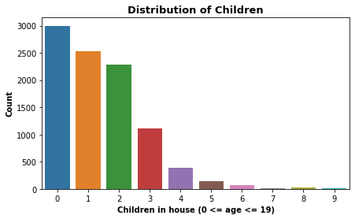

```python
plt.figure(figsize=(7,4))
sns.countplot(x = 'hogar_nin', data = train_data) # Number of children 0 to 19 in household
plt.title("Distribution of Children", fontsize = 13, fontweight="bold")
plt.xlabel("Children in house (0 <= age <= 19)", fontweight="bold")
plt.ylabel('Count', fontweight="bold")
plt.show()
```

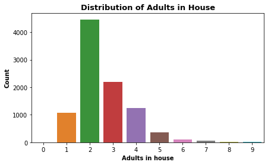

```python
plt.figure(figsize=(7,4))
sns.countplot(x = 'hogar_adul', data = train_data) # Number of adults in household
plt.title("Distribution of Adults in House", fontsize = 13, fontweight="bold")
plt.xlabel("Adults in house", fontweight="bold")
plt.ylabel('Count', fontweight="bold")
plt.show()
```

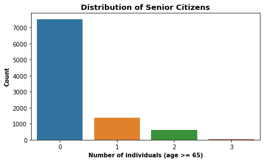

```python
plt.figure(figsize=(7,4))
sns.countplot(x = 'hogar_mayor', data = train_data)
plt.title("Distribution of Senior Citizens", fontsize = 13, fontweight="bold")
plt.xlabel("Number of individuals (age >= 65)", fontweight="bold")
plt.ylabel('Count', fontweight="bold")
plt.show()
```

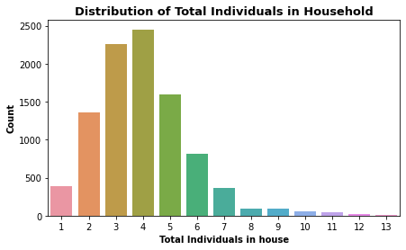

```python
plt.figure(figsize=(7,4))
sns.countplot(x = 'hogar_total', data = train_data ) # Number of total individuals in the household
plt.title("Distribution of Total Individuals in Household", fontsize = 13, fontweight="bold")
plt.xlabel("Total Individuals in house", fontweight="bold")
plt.ylabel('Count', fontweight="bold")
plt.show()
```

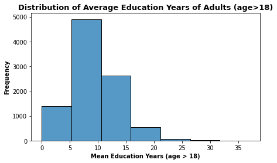

```python
plt.figure(figsize=(7,4))
sns.histplot(x = 'meaneduc', data = train_data, bins=7) # average years of education for adults (18+)
plt.title("Distribution of Average Education Years of Adults (age>18)", fontsize = 13, fontweight="bold")
plt.xlabel("Mean Education Years (age > 18)", fontweight="bold")
plt.ylabel('Frequency', fontweight="bold")
plt.show()
```

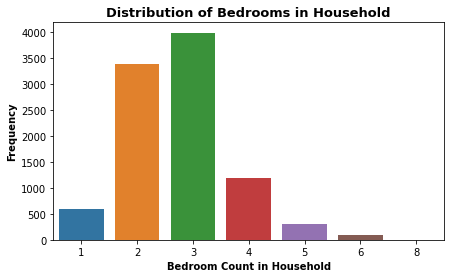

```python
plt.figure(figsize=(7,4))
sns.countplot(x = 'bedrooms', data = train_data) # number of bedrooms
plt.title("Distribution of Bedrooms in Household", fontsize = 13, fontweight="bold")
plt.xlabel("Bedroom Count in Household", fontweight="bold")
plt.ylabel('Frequency', fontweight="bold")
plt.show()
```

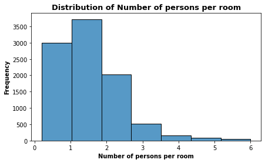

```python
plt.figure(figsize=(7,4))
sns.histplot(x = 'overcrowding' , data = train_data, bins = 7) # Number of persons per room
plt.title("Distribution of Number of persons per room", fontsize = 13, fontweight="bold")
plt.xlabel("Number of persons per room", fontweight="bold")
plt.ylabel('Frequency', fontweight="bold")
plt.show()
```

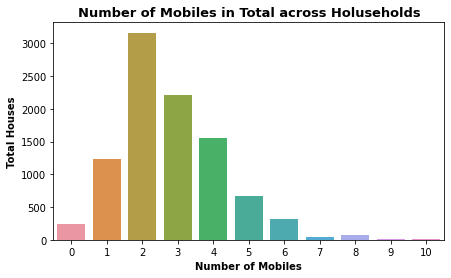

```python
plt.figure(figsize=(7,4))
sns.countplot(x = 'qmobilephone' , data = train_data)
plt.title("Number of Mobiles in Total across Holuseholds", fontsize = 13, fontweight="bold")
plt.xlabel("Number of Mobiles", fontweight="bold")
plt.ylabel('Total Houses', fontweight="bold")
plt.show()
```

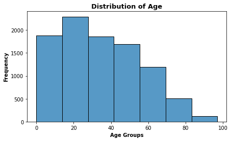

```python
plt.figure(figsize=(7,4))
sns.histplot(x =  'age', data = train_data, bins = 7) # Age in years
plt.title("Distribution of Age", fontsize = 13, fontweight="bold")
plt.xlabel("Age Groups", fontweight="bold")
plt.ylabel('Frequency', fontweight="bold")
plt.show()
```

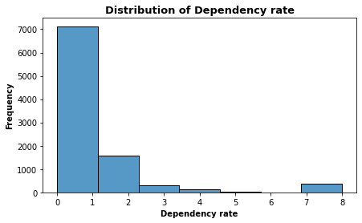

```python
plt.figure(figsize=(7,4))
sns.histplot(x = 'dependency', data = train_data, bins = 7);
plt.title('Distribution of Dependency rate', fontsize = 13, fontweight="bold")
plt.xlabel('Dependency rate', fontweight="bold")
plt.ylabel('Frequency', fontweight="bold")
plt.show()
```

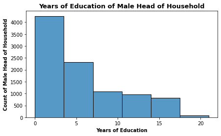

```python
plt.figure(figsize=(7,4))
sns.histplot(x = 'edjefe', data = train_data, bins = 6)  # years of education of male head of household
plt.title('Years of Education of Male Head of Household', fontsize = 13, fontweight="bold")
plt.xlabel('Years of Education', fontweight="bold")
plt.ylabel('Count of Male Head of Household', fontweight="bold")
plt.show()
```

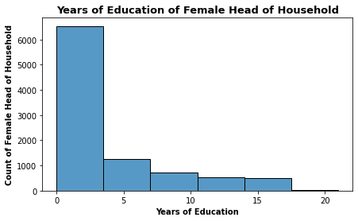

```python
plt.figure(figsize=(7,4))
sns.histplot(x = 'edjefa', data = train_data, bins = 6) # years of education of female head of household
plt.title('Years of Education of Female Head of Household', fontsize = 13, fontweight="bold")
plt.xlabel('Years of Education', fontweight="bold")
plt.ylabel('Count of Female Head of Household', fontweight="bold")
plt.show()
```